# Prediction, Bootstrapping and Monte Carlo Analyses Based on Linear Mixed Models with QAPE 2.0 Package

## Bootstrap procedures

The [**qape**](https://CRAN.R-project.org/package=qape) package provides three main types of bootstrap algorithms: the parametric bootstrap, the residual bootstrap and the double-bootstrap.

The parametric bootstrap procedure is implemented according to (González-Manteiga et al. 2007) and (González-Manteiga et al. 2008) and could be described in the following steps:

1. based on $n$ observations of the dependent and independent variables ($\mathbf{Y}_s$, $\mathbf{X}_s$ and $\mathbf{Z}_s$) estimate $\boldsymbol{\psi}$ to obtain the vector of estimates $\boldsymbol{\hat{\psi}}$,
2. generate $B$ realizations $y_{i}^{*(b)}$ of $Y_{i}$, under the $LMM(\mathbf{X}, \mathbf{Z}, \hat{\boldsymbol{\psi}})$ and multivariate normality of random effects and random components obtaining  
   $\mathbf{y}^{*(b)}=\begin{bmatrix} y_{1}^{*(b)} & ... & y_{i}^{*(b)} &... & y_{N}^{*(b)} \end{bmatrix}^T$, where $i=1, 2, ... ,N$ and $b=1, 2, ... ,B$,
3. decompose the vector $\mathbf{y}^{*(b)}$ as follows $\begin{bmatrix} \mathbf{y}_s^{*(b)T} & \mathbf{y}_r^{*(b)T} \end{bmatrix}^T$,
4. in the $b$th iteration ($b=1,2,...,B$)
   1. compute the bootstrap realization $\theta^{*(b)}=\theta^{*(b)}(\mathbf{y}^{*(b)},\boldsymbol{\hat{\psi}})$ of random variable $\theta$,
   2. obtain the vector of estimates $\boldsymbol{\hat{\psi}}^{*(b)}$ using $\mathbf{y}_s^{*(b)}$ and compute the bootstrap realization of predictor $\hat{\theta}$ denoted by $\hat{\theta}^{*(b)}(\mathbf{y}_s^{*(b)},\boldsymbol{\hat{\psi}}^{*(b)})$ based on $LMM(\mathbf{X}, \mathbf{Z}, \boldsymbol{\hat{\psi}}^{*(b)})$,
   3. compute bootstrap realizations of prediction error $U^*$ denoted by $u^*$ and for the $b$th iteration given by:
      $$\label{u*b}
      u^{*(b)}=\hat{\theta}^{*(b)}(\mathbf{y}_s^{*(b)},\boldsymbol{\hat{\psi}}^{*(b)})-\theta^{*(b)}
      (\mathbf{y}^{*(b)},\boldsymbol{\hat{\psi}})
      =\hat{\theta}^{*(b)}-\theta^{*(b)}, (\#eq:u*b)$$
5. compute the parametric bootstrap estimators of prediction accuracy measures: RMSE and QAPE replacing prediction errors $U$ in (@ref(eq:eq0)) and (@ref(eq:eq1)) by their bootstrap realizations.

Another possible method to estimate the prediction accuracy measures is the residual bootstrap. In what follows, we use the notation $srswr(\mathbf{A}, m)$ to indicate the outcome of taking a simple random sample with replacement of size $m$ of rows of matrix $\mathbf{A}$. If $\mathbf{A}$ is a vector, it simplifies to a simple random sample with replacement of size $m$ of elements of $\mathbf{A}$.

To obtain the algorithm of the residual bootstrap, it is enough to replace step 2 of the parametric bootstrap procedure presented above with the following procedure of the population data generation based on (@ref(eq:LMMa)):

- generate $B$ population vectors of the variable of interest, denoted by $\mathbf{y}^{*(b)}$ as
  $$\label{LMMboot}
  \mathbf{y}^{*(b)}=\mathbf{X}\hat{\boldsymbol{\beta}} +
  \mathbf{Z}_1\mathbf{v}^{*(b)}_1+...+\mathbf{Z}_l\mathbf{v}^{*(b)}_l+...+\mathbf{Z}_L\mathbf{v}^{*(b)}_L+\mathbf{e}^{*(b)}, (\#eq:LMMboot)$$
  where $\hat{\boldsymbol{\beta}}$ is an estimator (e.g. REML) of ${\boldsymbol{\beta}}$, $\mathbf{e}^{*(b)}$ is a vector of dimension $N \times 1$ defined as $srswr(col_{1 \leq i \leq n } \hat{{e}}_{i}, N)$, where $\hat{{e}}_{i}$ ($i=1,2,...,n$) are residuals, $\mathbf{v}^{*(b)}_l$ (for $1,2,...,L$) is the vector of dimension $K_l J_l \times 1$ built from the columns of the matrix: $srswr \left( \left[ \begin{array}{ccccc} \hat{\mathbf{v}}_{l1} & \dots & \hat{\mathbf{v}}_{lk} & \dots & \hat{\mathbf{v}}_{lK_l} \end{array} \right], J_l \right)$ of dimension $J_l \times K_l$, where $\hat{\mathbf{v}}_{lk}$ are estimates of elements of random effects vector (@ref(eq:vl)).

The next 3–5 steps in this procedure are analogous to steps in the parametric bootstrap procedure.

In the above-described step, it can be seen that if more than one vector of random effect is assumed at the $l$th level of grouping, then the elements are not sampled with replacement independently. In this case, rows of the matrix formed by these vectors are sampled with replacement.

The residual bootstrap algorithm can also be performed with so-called "correction procedure". This procedure, which can improve the properties of the residual bootstrap estimators due to the underdispersion of the uncorrected residual bootstrap distributions, is presented in the supplementary document for this paper.

## Bootstrap in [**qape**](https://CRAN.R-project.org/package=qape)

Two bootstrap procedures are implemented in separate functions: `bootPar()` (the parametric bootstrap) and `bootRes()` (the residual bootstrap). According to the general Procedure 1, the step preceding the bootstrap procedure in both functions is the definition of the predictor object. It must be one of the following: `EBLUP`, `ebpLMMne` or `plugInLMM`. This object has to be passed to `bootPar()` or `bootRes()` as the input parameter `predictor`. The other input parameters are intuitive: `B` - the number of bootstrap iterations and `p` - order of quantiles in the estimated QAPEs.

The additional input parameter in `bootRes()` is a logical condition called `correction`, which makes it possible to include an additional correction term for both random effects and random components, presented in the supplementary document for this paper, to avoid the problem of underdispersion of residual bootstrap distributions.

The main output values in both functions are basically the measures: `estRMSE` and `estQAPE` computed based on (@ref(eq:eq0)) and (@ref(eq:eq1)), respectively, where prediction errors are replaced by their bootstrap realizations. There is also the output `error` being the vector of bootstrap realizations of prediction errors, which is useful e.g. in in-depth analysis of the prediction accuracy and for graphical presentation of results. To estimate these accuracy measures, we use below the residual bootstrap with the correction procedure.

As previously stated, our package utilizes the `lmer()` function from the [**lme4**](https://CRAN.R-project.org/package=lme4) package for estimating model parameters. However, this function has been known to generate convergence warnings in certain situations, listed for example by (Bates et al. 2015) p. 25, when the estimated variances of random effects are close to zero. Such scenarios may occur when models are estimated for smaller or medium-sized datasets, when complex variance-covariance structures are assumed, or when the grouping variable considered for random effects has only a few levels. Although we have not observed such issues estimating model parameters based on the original dataset required to compute values of the predictors in previous sections, bootstrapping or Monte Carlo simulations are more complex cases. This is because, based on the estimates of model parameters, the values of the dependent variables are generated $B$ times, and then model parameters are estimated in each out of $B$ iterations. Therefore, in at least some iterations, dependent variable values may be randomly generated giving realizations, where the variance of the random effect is relatively close to zero. As a result, estimates of model parameters can be obtained; however, convergence issues implying warnings may occur. In such cases, there are at least two possible solutions. The first option is to discard iterations with warnings, which would imply that the dependent variable would not follow the assumed model as required, but instead only its conditional version with relatively high values of variances of random effects. It will imply overdispersed bootstrap distribution of random effects, which will affect the bias of the bootstrap estimators of accuracy measures. The second option is to consider all generated realizations, despite convergence warnings, as long as the parameters can be estimated for all iterations. We opted for the latter solution, as argued in (Bates et al. 2015) p. 25, who noted that "being able to fit a singular model is an advantage: when the best fitting model lies on the boundary of a constrained space".

### Example 2

The analyses presented in Example 1 are continued. We extend the previous results to include the issue of estimating the prediction accuracy of the considered predictors. The use of functions for this estimation primarily requires an object of class predictor, here "myplugin".

```r
> class(myplugin)
[1] "plugInLMM"
```

The short chunk of the R code presents the residual bootstrap estimators of the RMSE (`estRMSE`) and the QAPE (`estQAPE`) of the PLUG-IN predictors (`plugin`) of previously analyzed three characteristics of radon measurements in county no. 26: the arithmetic mean, geometric mean and median. In this and subsequent examples we make the computations for relatively high number of iterations allowing, in our opinion, to get reliable results. These results are also used to prepare Figure @ref(fig:hist). However, the computations are time-consuming. The supplementary R file contains the same chunks of the code but the number of iterations applied is smaller in order to execute the code swiftly.

```r
> # accuracy measures estimates based on
> # the residual bootstrap with the correction:
> B <- 500 # number of bootstrap iterations
> p <- c(0.75, 0.9) # orders of Quantiles of Absolute Prediction Error
> set.seed(1056)
> residBoot <- bootRes(myplugin, B, p, correction = TRUE)
> # values of estimated RMSEs of the predictor of three characteristics:
> # the arithmetic mean, geometric mean and median of radon measurements, respectively:
> residBoot$estRMSE
[1] 0.1848028 0.2003681 0.2824359
> # values of estimated QAPEs
> # (of order 0.75 in the first row, and of order 0.9 in the second row)
> # of the predictor of three characteristics:
> # the arithmetic mean, geometric mean and median of radon measurements,
> # in the 1st, 2nd and 3rd column, respectively:
> residBoot$estQAPE
         [,1]      [,2]      [,3]
75% 0.1533405 0.2135476 0.2908988
90% 0.2813886 0.3397411 0.4374534
```

Let us concentrate on interpretations of estimators of accuracy measures for the predictor of the geometric mean, i.e. the second value of `residBoot$estRMSE`, and values in the second column of `residBoot$estQAPE`. It is estimated that the average difference between predicted values of the geometric mean and their unknown realizations equals $0.2003681$ picoCurie per liter. Furthermore, it is estimated that at least $75\%$ of absolute prediction errors of the predictor of the geometric mean are smaller or equal to $0.2135476$ picoCurie per liter and at least $25\%$ of absolute prediction errors of the predictor are higher or equal to $0.2135476$ picoCurie per liter. Finally, it is estimated that at least $90\%$ of absolute prediction errors of the predictor of the geometric mean are smaller or equal to $0.3397411$ picoCurie per liter and at least $10\%$ of absolute prediction errors of the predictor are higher or equal to $0.3397411$ picoCurie per liter. The distributions of bootstrap absolute prediction errors with values of estimated RMSEs and QAPEs for the considered three prediction problems are presented in Figure @ref(fig:hist).

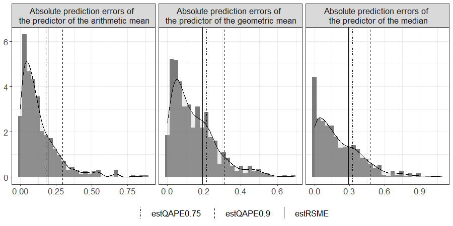

The histograms of bootstrap absolute prediction errors for myplugin (for PLUG-IN predictors of the arithmetic mean, geometric mean and median) for B=500

Since the assumption of normality is not met, the parametric bootstrap should not be used in this case. For this reason, we do not present the results for this method below, although – but for illustrative purposes only – they are presented in the supplementary R file. Moreover, these analyses can also be conducted using `bootParFuture()` and `bootResFuture()` functions where parallel computing algorithms are applied. The input arguments and the output of these functions are the same as in `bootPar()` and `bootRes()`. Examples based on these functions are also included in the supplementary R file.

## Bootstrap under the misspecified model in [**qape**](https://CRAN.R-project.org/package=qape)

The [**qape**](https://CRAN.R-project.org/package=qape) package also allows to use predictors under a model different from the assumed one (e.g. a simpler or more robust model), but estimate its accuracy under the assumed model. In this case, the parametric and residual bootstrap procedures are implemented in `bootParMis()` and `bootResMis()` functions. These functions allow to estimate the accuracy of two predictors under the model correctly specified for the first of them. Of course, it is expected that the estimated accuracy of the first predictor will be better than of the second one, but the key issue can be the difference between estimates of accuracy measures. A small difference, even to the second predictor’s disadvantage, may be treated by the user as an argument for using the second predictor due to its properties, such as robustness or simplicity.

The considered functions allow to estimate the accuracy of two predictors, which belong to the class `plugInLMM`, under the model used to define the first of them. The remaining arguments are the same as in `bootPar()` and `bootRes()` functions: `B` - the number of bootstrap iterations, and `p` - orders of QAPE estimates to be taken into account.

The output results of `bootParMis()` and `bootResMis()` include – similarly to `bootPar()` and `bootRes()` functions – estimates of the RMSEs and QAPEs of both predictors (denoted here by: `estRMSElmm`, `estRMSElmmMis`, `estQAPElmm` and `estQAPElmmMis`), and boostrap realizations of their prediction errors (`errorLMM` and `errorLMMmis`).

### Example 3

In this example, we study the same accuracy measures as in Example 2, but the aim is to compare the predictor `myplugin` and other predictor defined under the misspecified LMM. First, the misspecified model has to be defined, and a relevant predictor has to be computed.

```r
> fixed.part.mis <- '1'
> random.part.mis <- '(1|county)'
> myplugin.mis <- plugInLMM(YS, fixed.part.mis, random.part.mis, reg, con,
+                         weights = NULL, backTrans = backTransExp, thetaFun)
```

Having two objects: `myplugin` and `myplugin.mis`, one can proceed to a comparison by estimating bootstrap prediction accuracy performed using the residual bootstrap with correction procedure. In this case, we estimate the prediction accuracy of these two predictors under the model used to define the first of them.

```r
> set.seed(1056)
> residBootMis <- bootResMis(myplugin, myplugin.mis, B, p, correction = TRUE)
> # residual bootstrap with the correction RMSE estimators
> # of 'plugin' of: arithmetic mean, geometric mean and median
> # of radon measurements in county 26:
> residBootMis$estRMSElmm
[1] 0.1848028 0.2003681 0.2824359
> # residual bootstrap with the correction RMSE estimators
> # of 'plugin.mis' of: arithmetic mean, geometric mean and median
> # of radon measurements in county 26:
> residBootMis$estRMSElmmMis
[1] 0.1919184 0.3192304 0.2762137
> # residual bootstrap with the correction QAPE estimators of order 0.75 and 0.9
> # of 'plugin' of: arithmetic mean, geometric mean and median
> # of radon measurements in county 26:
> residBootMis$estQAPElmm
         [,1]      [,2]      [,3]
75% 0.1533405 0.2135476 0.2908988
90% 0.2813886 0.3397411 0.4374534
> # residual bootstrap with the correction QAPE estimators of order 0.75 and 0.9
> # of 'plugin.mis' of: arithmetic mean, geometric mean and median
> # of radon measurements in county 26:
> residBootMis$estQAPElmmMis
         [,1]      [,2]      [,3]
75% 0.2267062 0.3802836 0.3255197
90% 0.2813787 0.4970726 0.4489399
```

The results, presented above, were obtained for the same number of bootstrap iterations as in Example 2 ($B = 500$). If we compare, under the model defined in `plugin`, estimated RMSEs of `plugin` and `plugin.mis` predictors of the geometric mean given by $0.2003681$ and $0.3192304$ picoCurie per liter, respectively, we can state that the estimated accuracy (measured by RMSE estimators) of the first predictor is better comparing with the second one. If we are not interested in the average accuracy measures but in the right tail of the distribution of prediction errors, we can use estimates of QAPE of order 0.9 to compare the accuracy. The result for the `plugin.mis` of the geometric mean equals to $0.4970726$ picoCurie per liter, and it is higher comparing with $0.3397411$ picoCurie per liter obtained for `plugin` for the same prediction problem. Hence, in this case, the accuracy comparison based both on the RMSE and QAPE leads to the same finding.

## Monte Carlo simulation analyses

In the previous section, our aim was to estimate the prediction accuracy under correctly specified or misspecified model. In this section, we do not estimate the accuracy, but we approximate the true prediction accuracy under the specified model in the Monte Carlo simulation study. The crucial difference is that in this case, the model parameters used are obtained based on the whole population dataset, not the sample. If the number of iterations is large enough, we can treat the computed values of the measures as their true values, which are unknown in practice.

The last step of the analysis in [**qape**](https://CRAN.R-project.org/package=qape) package presented in Procedure 1 is the Monte Carlo (MC) simulation analysis of:

- properties of predictors
- and properties of parametric, residual and double bootstrap estimators of accuracy measures.

The whole Monte Carlo procedure is as follows.

**Procedure 2**. *Model-based Monte Carlo simulation analyses in [**qape**](https://CRAN.R-project.org/package=qape)*

1. *define the population vector of the dependent variable and the population matrix of auxiliary variables,*
2. *provide the information on the division of the population into the sampled and non-sampled part,*
3. *define $\theta$ - the characteristics of the response variable to be predicted,*
4. *define the predictors $\hat{\theta}$ and accuracy measures estimators which properties are to be assessed,*
5. *define the model to be used to generate realizations of the values of the dependent variable and estimate its parameters based on population data,*
6. *For k=1, 2, ..., K*
   1. *generate the population vector of the response variable based on the assumed model,*
   2. *based on population data, compute the characteristics $\theta$, denoted by $\theta_k$,*
   3. *based on sample data, estimate the parameters of the LMM,*
   4. *based on sample data, compute values of predictors $\hat{\theta}$, denoted by $\hat{\theta}_k$,*
   5. *based on sample data, estimate the accuracy of $\hat{\theta}$ using bootstrap methods,*
7. *End For*
8. *compute accuracy measures of predictors using $\hat{\theta}_k$ and $\theta_k$ (for $k=1,2, ..., K$),*
9. *compute accuracy measures of estimators of prediction accuracy measures.*

## Monte Carlo analyses in [**qape**](https://CRAN.R-project.org/package=qape)

### Example 4

In the example, an MC simulation is carried out assuming the `myplugin` predictor. The goal is to approximate the true accuracy of the prediction assuming model (@ref(eq:radon-model)). Hence, in the package [**qape**](https://CRAN.R-project.org/package=qape), all input predictor objects in the function `mcLMMmis` have to be defined as `myplugin`.

```r
> # input arguments:
predictorLMMmis <- myplugin # to define the model
predictorLMM <- myplugin # which properties are assessed in the simulation study
predictorLMM2 <- myplugin  # which properties are assessed in the sim. study
```

Except that no modification of covariance matrices has to be used.

```r
# diag. elements of the covariance matrix of random components are divided by:
ratioR <- 1
# diag. elements of the covariance matrix of random effects are divided by:
ratioG <- 1
```

We specify the number of Monte Carlo iterations.

```r
K <- 500 # the number of MC iterations
```

The analysis is conducted in the object `MC`.

```r
> set.seed(1086)
> MC <- mcLMMmis(Ypop, predictorLMMmis, predictorLMM, predictorLMM2,
+                        K, p, ratioR, ratioG)
> # relative bias of 'predictorLMM'
> # of the arithmetic mean, geometric mean and median in county 26 (in %):
> MC$rBlmm
[1] -1.73208393 -0.04053178 -5.22355236
```

Results of the relative biases are obtained. It is seen, that under the assumed model the values of the considered predictor of the geometric mean (the second value of `MC$rBlmm`) are smaller than possible realizations of the geometric mean on average by $0.04053178\%$. In turn, the relative RMSEs are as follows.

```r
> # relative RMSE of 'predictorLMM'
> # of the arithmetic mean, geometric mean and median in county 26 (in %):
> MC$rRMSElmm
[1] 3.429465 4.665810 7.146678
```

In the considered case, the average difference between predicted values of the geometric mean and its possible realizations (the second value of `MC$rRMSElmm`) equals $4.665810\%$. It should be noted that this value can be treated as the true value of the relative RMSE (if the number of iterations is large enough), not the estimated value obtained in Examples 2 and 3.

Finally, QAPEs of orders 0.75 and 0.9 are considered.

```r
> # QAPE of order 0.75 and 0.9 of 'predictorLMM'
> # of the arithmetic mean, geometric mean and median in county 26:
> MC$QAPElmm
         [,1]      [,2]      [,3]
75% 0.1491262 0.1989504 0.2919221
90% 0.2895684 0.2959457 0.4728064
```

Let us interpret the results presented in the second column of `MC$QAPElmm`. At least $75\%$ ($90\%$) of absolute prediction errors of the predictor of the geometric mean are smaller or equal to $0.1989504$ ($0.2959457$) picoCurie per liter and at least $25\%$ ($10\%$) of absolute prediction errors of the predictor are higher or equal to $0.1989504$ ($0.2959457$) picoCurie per liter. Similar to the values of the rRMSEs in the previous code chunk, the values can be considered to be true QAPE values, not the estimates presented in Examples 2 and 3.

In Example 4, the accuracy of one predictor under the model used to define this predictor was presented. A more complex version of the simulation study, where the properties of two predictors are studied under the model defined by the third predictor, is presented in the supplementary R file. What is more, the [**qape**](https://CRAN.R-project.org/package=qape) package also allows to use `mcBootMis()` function to conduct MC analyses of properties of accuracy measure estimators (estimators of MSEs and QAPEs) of two predictors (which belong to the class `plugInLMM`) declared as arguments. The model used in the simulation study is declared in the first predictor, but the properties of accuracy measures estimators of both predictors are studied. Output results of `mcBootMis()` covers simulation results on properties of different accuracy measures estimators, including the relative biases and relative RMSEs of the parametric bootstrap MSE estimators of both predictors. The same simulation-based statistics but for parametric bootstrap QAPE estimators are also included. Other bootstrap methods, including the residual bootstrap with and without the correction procedure, are also taken into account. The full list of output arguments of `mcBootMis()` function are presented in `qape-manual` file, cf. (Wolny-Dominiak and Żądło 2023).

## Conclusions

The package enables R users to make predictions and assess the accuracy under linear mixed models based on different methods in a fast and intuitive manner – not only based on the RMSE but also based on Quantiles of Absolute Prediction Errors. It also covers functions which allow to conduct Monte Carlo simulation analyses of properties of the methods of users interest. Its main advantage, compared to other packages, is the considerable flexibility in terms of defining the model (as in the [**lme4**](https://CRAN.R-project.org/package=lme4) package) and the predicted characteristic, but also the transformation of the response variable.

In our opinion, the package is useful for scientists, practitioners and decision-makers in all areas of research where accurate estimates and forecasts for different types of data (including cross-sectional and longitudinal data) and for different characteristics play the crucial role. We believe that it will be of special interest to survey statisticians interested in the prediction for subpopulations with small or even zero sample sizes, called small areas.

Bates, Douglas, Martin Mächler, Ben Bolker, and Steve Walker. 2015. “Fitting Linear Mixed-Effects Models Using lme4.” *Journal of Statistical Software* 67 (1): 1–48. https://doi.org/10.18637/jss.v067.i01.

Battese, George E, Rachel M Harter, and Wayne A Fuller. 1988. “An Error-Components Model for Prediction of County Crop Areas Using Survey and Satellite Data.” *Journal of the American Statistical Association* 83 (401): 28–36.

Boubeta, Miguel, Marı́a José Lombardı́a, and Domingo Morales. 2016. “Empirical Best Prediction Under Area-Level Poisson Mixed Models.” *Test* 25 (3): 548–69.

Breidenbach, Johannes. 2018. *JoSAE: Unit-Level and Area-Level Small Area Estimation*. https://CRAN.R-project.org/package=JoSAE.

Bühlmann, Hans, and Alois Gisler. 2005. *A Course in Credibility Theory and Its Applications*. Springer.

Cantoni, Eva, Nadège Jacot, and Paolo Ghisletta. 2021. “Review and Comparison of Measures of Explained Variation and Model Selection in Linear Mixed-Effects Models.” *Econometrics and Statistics*.

Christiaensen, Luc, Peter Lanjouw, Jill Luoto, and David Stifel. 2012. “Small Area Estimation-Based Prediction Methods to Track Poverty: Validation and Applications.” *The Journal of Economic Inequality* 10 (2): 267–97.

Chwila, Adam, and Tomasz Żądło. 2019. “On Properties of Empirical Best Predictors.” *Communications in Statistics-Simulation and Computation*, 1–34.

Cook, Dianne, Deborah F Swayne, and Andreas Buja. 2007. *Interactive and Dynamic Graphics for Data Analysis: With r and GGobi*. Vol. 1. Springer.

Fay III, Robert E, and Roger A Herriot. 1979. “Estimates of Income for Small Places: An Application of James-Stein Procedures to Census Data.” *Journal of the American Statistical Association* 74 (366a): 269–77.

Frees, Edward W, Virginia R Young, and Yu Luo. 1999. “A Longitudinal Data Analysis Interpretation of Credibility Models.” *Insurance: Mathematics and Economics* 24 (3): 229–47.

Gelman, Andrew, and Jennifer Hill. 2006. *Data Analysis Using Regression and Multilevel/Hierarchical Models*. 1st edition. Cambridge ; New York: Cambridge University Press.

Gelman, Andrew, and Iain Pardoe. 2006. “Bayesian Measures of Explained Variance and Pooling in Multilevel (Hierarchical) Models.” *Technometrics* 48 (2): 241–51.

González-Manteiga, Wenceslao, Maríá José Lombardı́a, Isabel Molina, Domingo Morales, and Laureano Santamarı́a. 2007. “Estimation of the Mean Squared Error of Predictors of Small Area Linear Parameters Under a Logistic Mixed Model.” *Computational Statistics & Data Analysis* 51: 2720–33.

———. 2008. “Bootstrap Mean Squared Error of Small-Area EBLUP.” *Journal of Statistical Computation and Simulation* 78: 443–62.

Henderson, Charles R. 1950. “Estimation of Genetic Parameters.” *Biometrics* 6 (2): 186–87.

Hobza, Tomáš, and Domingo Morales. 2016. “Empirical Best Prediction Under Unit-Level Logit Mixed Models.” *Journal of Official Statistics* 32 (3): 661–92.

Jiang, Jiming. 1996. “REML Estimation: Asymptotic Behavior and Related Topics.” *The Annals of Statistics* 24 (1): 255–86.

Kackar, Raghu N, and David A Harville. 1981. “Unbiasedness of Two-Stage Estimation and Prediction Procedures for Mixed Linear Models.” *Communications in Statistics-Theory and Methods* 10 (13): 1249–61.

Kreutzmann, Ann-Kristin, Sören Pannier, Natalia Rojas-Perilla, Timo Schmid, Matthias Templ, and Nikos Tzavidis. 2019. “The r Package Emdi for Estimating and Mapping Regionally Disaggregated Indicators.” *Journal of Statistical Software* 91.

Lefler, Maria Dolores Esteban, Domingo Morales Gonzalez, and Agustin Perez Martin. 2014. *Saery: Small Area Estimation for Rao and Yu Model*. https://CRAN.R-project.org/package=saery.

Lin, Chiayu, Andrew Gelman, Phillip N Price, and David H Krantz. 1999. “Analysis of Local Decisions Using Hierarchical Modeling, Applied to Home Radon Measurement and Remediation.” *Statistical Science* 14 (3): 305–37.

Loy, Adam. 2013. “Diagnostics for Mixed/Hierarchical Linear Models.” PhD thesis, Iowa State University.

Loy, Adam, and Heike Hofmann. 2014. “HLMdiag: A Suite of Diagnostics for Hierarchical Linear Models in R.” *Journal of Statistical Software* 56 (5): 1–28. https://www.jstatsoft.org/article/view/v056i05.

———. 2015. “Are You Normal? The Problem of Confounded Residual Structures in Hierarchical Linear Models.” *Journal of Computational and Graphical Statistics* 24 (4): 1191–1209.

Loy, Adam, Heike Hofmann, and Dianne Cook. 2017. “Model Choice and Diagnostics for Linear Mixed-Effects Models Using Statistics on Street Corners.” *Journal of Computational and Graphical Statistics* 26 (3): 478–92.

Molina, Isabel, and Yolanda Marhuenda. 2015. “sae: An R Package for Small Area Estimation.” *The R Journal* 7 (1): 81–98. https://journal.r-project.org/archive/2015/RJ-2015-007/RJ-2015-007.pdf.

Molina, Isabel, and JNK2010 Rao. 2010. “Small Area Estimation of Poverty Indicators.” *Canadian Journal of Statistics* 38 (3): 369–85.

Nero, AV, SM Leiden, DA Nolan, PN Price, S Rein, KL Revzan, HR Woolenberg, and AJ Gadgil. 1994. “Statistically Based Methodologies for Mapping of Radon’actual’concentrations: The Case of Minnesota.” *Radiation Protection Dosimetry* 56 (1-4): 215–19.

Permatasari, Novia, and Azka Ubaidillah. 2021. *Msae: Multivariate Fay Herriot Models for Small Area Estimation*. https://CRAN.R-project.org/package=msae.

Price, Phillip N., and Andrew Gelman. 2005. “Should You Measure the Radon Concentration in Your Home?” In *Statistics: A Guide to the Unknown*, 4th edition, 149–70. Belmont, CA: Duxbury Press.

Price, Phillip N, Anthony V Nero, and Andrew Gelman. 1996. “Bayesian Prediction of Mean Indoor Radon Concentrations for Minnesota Counties.” *Health Physics* 71 (6): 922–36.

Rao, John NK, and Isabel Molina. 2015. *Small Area Estimation*. John Wiley & Sons.

Rao, Jon NK, and Mingyu Yu. 1994. “Small-Area Estimation by Combining Time-Series and Cross-Sectional Data.” *Canadian Journal of Statistics* 22 (4): 511–28.

Royall, Richard M. 1976. “The Linear Least-Squares Prediction Approach to Two-Stage Sampling.” *Journal of the American Statistical Association* 71 (355): 657–64.

Wolny-Dominiak, Alicja, and Tomasz Żądło. 2020. “On Bootstrap Estimators of Some Prediction Accuracy Measures of Loss Reserves in a Non-Life Insurance Company.” *Communications in Statistics-Simulation and Computation*, 1–16.

———. 2023. *Qape: Quantile of Absolute Prediction Errors*. https://CRAN.R-project.org/package=qape.

Żądło, T. 2013. “On Parametric Bootstrap and Alternatives of MSE.” In *Proceedings of 31st International Conference Mathematical Methods in Economics*, 1081–86.

Żądło, Tomasz. 2017. “On Prediction of Population and Subpopulation Characteristics for Future Periods.” *Communications in Statistics-Simulation and Computation* 461 (10): 8086–8104.